# MolB-RTI vs Skim-RTI vs BrB-RTI — ancestry-call concordance (real counts, shared r=8)

Author

Fausto Rodríguez-Zapata

Published

June 26, 2026

**Repo:** sawers-rellan-labs/zealtiger

Cross-validation of ancestry source **#2 (SNP50K skim, ~0.4×)** against source **#5 (MolBreeding target sequencing)** for the BZea NILs genotyped on both platforms, with a third real-count platform — **BRB-seq 3′ bulk RNA-seq (~1.5–3×)** — layered in as an additional cross-check on the NILs it shares.

**BRB-seq layer (source #6).** GATK `CollectAllelicCounts` over the brbseq joint-called SNP sites gives per-sample `REF_COUNT`/`ALT_COUNT` with REF = B73 NAM v5 and ALT = observed alternate, so — like the skim and target sequencing — it is fed to RTIGER as **real allele counts** (`fit_rtiger_brbseq.R`, r = 8, MLE, no wsfilt: the brbseq sites are used as-is, since RNA-seq covers only expressed regions and overlaps the wideseq donor panel at too few markers to filter). BRB-seq run_full sequenced plates PN1–PN4 (SID 1–384), so it overlaps the comparison only on the **8 PN4 samples** (7 teosinte NILs + the `PN4_SID326` B73-bulk check); the PN6/PN12 NILs have no BRB-seq counterpart here. BRB-seq sections below are therefore restricted to those 8 samples, while the target-sequencing-vs-skim comparison keeps all 16.

**This is the real-count pipeline.** MolBreeding source #5 is **target-capture sequencing** (~110× depth, ~0.2% missing), *not* a hybridization array — so it is fed to RTIGER as **real allele counts** (`REF_COUNT`/`ALT_COUNT` from the GATK table), exactly like the skim, rather than the 0/1/2 pseudo-counts of the earlier array-style attempt.

**Two design choices:**

1. **No line-QC filter.** The array-era “Crappy”/`Good` split was driven by array het-rate; with real ~110× counts every sample is clean (missing ~0.2%), so **all 16 samples are kept** — 14 teosinte NILs + 2 B73-bulk checks. The checks are a built-in control (they should read ≈ pure recurrent).
2. **SNP filter (`wsfilt`).** Keep only markers overlapping the **wideseq teosinte-vs-B73 panel** (9,157 of the 20,347 lifted v5 SNPs are donor-informative, with consistent REF=B73 / ALT=teosinte polarity across sources). The full 20,347-SNP fit is shown alongside for reference.

**Rigidity r = 8 for both platforms** — matched to the skim’s per-taxon r=8 (Source 2), so the comparison uses one consistent rigidity rather than ad-hoc per-platform tuning. Calls are RTIGER segments on B73 NAM v5 (`name, chr, start_bp, end_bp, state`; 0 = recurrent/B73, 1 = het, 2 = homozygous donor).

> The consensus-map BC2S3 **simulation** (source #1) is a **null expectation** under the modeled recombination process (MaizeGDB consensus map, ~1,783 cM; `m=10` interference; BC2S3 pedigree), **not ground truth**.

**Naming.** Call sets are labelled `Source-Caller`. Sources: **Skim** (SNP50K ~0.4× skim), **MolB** (MolBreeding target-capture sequencing, ~110×), **BrB** (BRB-seq 3′ RNA-seq). Caller here is **RTI** = RTIGER, run on all three at a shared **r=8**. MolB has two RTIGER marker sets: **MolB-RTI (wsfilt)** (wideseq donor panel, 9,157 SNPs; the primary) and **MolB-RTI (full)** (all 20,347 lifted v5 SNPs). The consensus-map simulation is **Null**. (A 1 Mb-bin GMM-HMM caller, **BIN**, is compared elsewhere; it does not appear here.)

## Setup

```r
library(tidyverse); library(GenomicRanges); library(S4Vectors)
source("R/06_score_rtiger.R")

mb      <- read_csv(params$mb_calls,   show_col_types = FALSE)   # target-seq wsfilt, r=8
mb_full <- read_csv(params$mb_full,    show_col_types = FALSE)   # target-seq full,  r=8
skim    <- read_csv(params$skim_calls, show_col_types = FALSE)   # skim, per-taxon r=8
brb     <- read_csv(params$brb_calls,  show_col_types = FALSE)   # BRB-seq RNA, r=8 (no wsfilt)
smap    <- read_tsv(params$sample_map, show_col_types = FALSE)
sl      <- read_csv(params$seqlengths, show_col_types = FALSE)
sim_seg <- read_csv(params$sim_seg,    show_col_types = FALSE)

# common wideseq marker grid, from the filtered RTIGER count files
cf <- read_tsv(list.files(params$mb_counts, full.names = TRUE)[1],
               col_names = c("chr_label","bp","rb","rc","ab","ac"), show_col_types = FALSE)
grid    <- tibble(chr = as.integer(sub("chr","",cf$chr_label)), bp = cf$bp)
spacing <- sum(sl$len) / nrow(grid)

# samples present on both platforms (the 2 B73 checks have no skim NIL match)
samples <- intersect(unique(mb$name), unique(skim$name))
# BRB-seq overlaps only the PN4 subset (run_full = plates PN1-PN4)
brb_samples <- intersect(unique(brb$name), unique(mb$name))
cat(sprintf("MolB samples: %d (all kept, no QC) | shared with Skim: %d\n",
            n_distinct(mb$name), length(samples)))
```

```
MolB samples: 16 (all kept, no QC) | shared with Skim: 14
```

```r
cat(sprintf("BrB samples: %d | shared with MolB: %d | also with Skim: %d\n",
            n_distinct(brb$name), length(brb_samples),
            length(intersect(brb_samples, samples))))
```

```
BrB samples: 8 | shared with MolB: 8 | also with Skim: 7
```

```r
cat(sprintf("wideseq markers: %d (~%.0f kb spacing; r=8 detection limit ≈ %.1f Mb)\n",
            nrow(grid), spacing/1e3, 8*spacing/1e6))
```

```
wideseq markers: 9157 (~233 kb spacing; r=8 detection limit ≈ 1.9 Mb)
```

```r
donor_blocks <- function(seg) seg %>% arrange(name, chr, start_bp) %>% group_by(name, chr) %>%
  mutate(run = cumsum(c(TRUE, diff(state > 0) != 0)), donor = state > 0) %>% filter(donor) %>%
  group_by(name, chr, run) %>% summarise(size_mb = (max(end_bp)-min(start_bp))/1e6, .groups = "drop")
co_count <- function(seg) seg %>% arrange(name, chr, start_bp) %>% group_by(name, chr) %>%
  summarise(tr = sum(abs(diff(as.integer(state > 0)))), .groups = "drop") %>%
  group_by(name) %>% summarise(COs = sum(tr), .groups = "drop")
state_at <- function(df, s) {
  d <- df[df$name == s, ]
  d$state[findOverlaps(GRanges(grid$chr, IRanges(grid$bp, width = 1)),
                       GRanges(d$chr, IRanges(d$start_bp, d$end_bp)), select = "first")]
}
```

## Donor dosage & the B73-bulk control

Per-sample donor dosage (bp-weighted `state/2`). BC2S3 expectation ≈ 0.125; a flipped REF/ALT polarity would read ≈ 0.875. The two B73-bulk checks (`PN4_SID326`, `PN6_SID576`) should read ≈ 0 — a built-in validity test that needs no external truth.

```r
dosage <- function(seg) seg %>% mutate(len = end_bp - start_bp + 1) %>%
  group_by(name) %>% summarise(dosage = sum(len * state/2) / sum(len), .groups = "drop")
checks <- c("PN4_SID326", "PN6_SID576")
dose <- dosage(mb) %>% dplyr::rename(molb_wsfilt = dosage) %>%
  left_join(dosage(mb_full) %>% dplyr::rename(molb_full = dosage), by = "name") %>%
  left_join(dosage(skim)    %>% dplyr::rename(skim = dosage),       by = "name") %>%
  left_join(dosage(brb)     %>% dplyr::rename(brbseq = dosage),     by = "name") %>%
  mutate(is_B73_check = name %in% checks) %>% arrange(molb_full)
dose
```

| name | molb_wsfilt | molb_full | skim | brbseq | is_B73_check |
| --- | --- | --- | --- | --- | --- |
| PN4_SID326 | 0.001215697 | 0.007117173 | NA | 0.07597097 | TRUE |
| PN6_SID576 | 0.001250418 | 0.019576005 | NA | NA | TRUE |
| PN4_SID291 | 0.009383058 | 0.022931289 | 0.010560105 | 0.07385260 | FALSE |
| PN6_SID575 | 0.010196753 | 0.024603345 | 0.009233704 | NA | FALSE |
| PN6_SID524 | 0.041050796 | 0.052999573 | 0.037340708 | NA | FALSE |
| PN4_SID290 | 0.043208347 | 0.057898184 | 0.053101510 | 0.03369334 | FALSE |
| PN4_SID320 | 0.063424680 | 0.071235978 | 0.069222155 | 0.08754562 | FALSE |
| PN6_SID509 | 0.059323678 | 0.071746753 | 0.062084669 | NA | FALSE |
| PN4_SID293 | 0.059802185 | 0.076322098 | 0.052061134 | 0.05516685 | FALSE |
| PN6_SID568 | 0.072183430 | 0.083357058 | 0.055281452 | NA | FALSE |

[output cut: 6 more lines]

```r
cat(sprintf("mean donor dosage — MolB-RTI full %.3f | MolB-RTI wsfilt %.3f | Skim-RTI (shared) %.3f | BrB-RTI (shared) %.3f\n",
            mean(dose$molb_full), mean(dose$molb_wsfilt),
            mean(dose$skim[!is.na(dose$skim)]),
            mean(dose$brbseq[!is.na(dose$brbseq)])))
```

```
mean donor dosage — MolB-RTI full 0.079 | MolB-RTI wsfilt 0.070 | Skim-RTI (shared) 0.063 | BrB-RTI (shared) 0.055
```

```r
cat(sprintf("B73-bulk checks dosage (MolB-RTI full): %s — expect ≈ 0\n",
            paste(sprintf("%s=%.3f", checks,
                          dose$molb_full[match(checks, dose$name)]), collapse = ", ")))
```

```
B73-bulk checks dosage (MolB-RTI full): PN4_SID326=0.007, PN6_SID576=0.020 — expect ≈ 0
```

## State on the common grid

```r
paired <- map_dfr(samples, function(s) {
  a <- state_at(mb, s); k <- state_at(skim, s); ok <- !is.na(a) & !is.na(k)
  tibble(name = s, molb = a[ok], skim = k[ok])
})
```

## Confusion matrix — MolB-RTI vs Skim-RTI

Rows = MolB-RTI state (wsfilt, r=8), cols = Skim-RTI (per-taxon r=8); cell = count (row %).

```r
cm <- table(molb = factor(paired$molb, 0:2), skim = factor(paired$skim, 0:2))
overall <- sum(diag(cm)) / sum(cm)
prop <- sweep(cm, 1, rowSums(cm), "/")
disp <- matrix(sprintf("%d (%.1f%%)", cm, 100*prop), nrow = 3,
               dimnames = list(`MolB-RTI \\ Skim-RTI` = c("0 recurrent","1 het","2 donor"),
                               c("0 recurrent","1 het","2 donor")))
knitr::kable(disp, align = "r",
             caption = sprintf("MolB-RTI (rows) vs Skim-RTI (cols): count (row %%). Overall concordance %.3f.", overall))
```

MolB-RTI (rows) vs Skim-RTI (cols): count (row %). Overall concordance 0.934.

|  | 0 recurrent | 1 het | 2 donor |
| --- | --- | --- | --- |
| 0 recurrent | 107312 (99.0%) | 441 (0.4%) | 664 (0.6%) |
| 1 het | 3940 (26.6%) | 8797 (59.3%) | 2090 (14.1%) |
| 2 donor | 1015 (22.1%) | 236 (5.1%) | 3338 (72.7%) |

```r
dp <- paired$molb %in% c(1, 2)
cat(sprintf("MolB-RTI donor-present markers: %d | Skim-RTI also donor-present: %.1f%%\n",
            sum(dp), 100*mean(paired$skim[dp] %in% c(1,2))))
```

```
MolB-RTI donor-present markers: 19416 | Skim-RTI also donor-present: 74.5%
```

```r
cat(sprintf("MolB-RTI homozygous-donor markers: %d | Skim-RTI also hom-donor: %.1f%%\n",
            sum(paired$molb == 2), 100*mean(paired$skim[paired$molb == 2] == 2)))
```

```
MolB-RTI homozygous-donor markers: 4589 | Skim-RTI also hom-donor: 72.7%
```

## BrB-RTI cross-check (3′ RNA-seq, shared PN4 NILs)

BrB-RTI state on the common grid for the 8 shared samples, against MolB-RTI (reference) and Skim-RTI. RNA-seq covers only expressed regions at low depth, so RTIGER sees sparse ALT reads and fragments — treat BrB-RTI as a noisy qualitative read of donor presence, not a segment-resolution caller.

```r
paired_b <- map_dfr(brb_samples, function(s) {
  g <- state_at(mb, s); r <- state_at(brb, s); k <- state_at(skim, s)
  ok <- !is.na(g) & !is.na(r)
  tibble(name = s, molb = g[ok], brbseq = r[ok],
         skim = if (s %in% samples) k[ok] else NA_integer_)
})
```

Rows = BrB-RTI state, cols = MolB-RTI (wsfilt, r=8); cell = count (row %).

```r
cm_bg <- table(brbseq = factor(paired_b$brbseq, 0:2), molb = factor(paired_b$molb, 0:2))
prop  <- sweep(cm_bg, 1, rowSums(cm_bg), "/")
disp  <- matrix(sprintf("%d (%.1f%%)", cm_bg, 100*prop), nrow = 3,
                dimnames = list(`BrB-RTI \\ MolB-RTI` = c("0 recurrent","1 het","2 donor"),
                                c("0 recurrent","1 het","2 donor")))
knitr::kable(disp, align = "r",
             caption = sprintf("BrB-RTI (rows) vs MolB-RTI (cols): count (row %%). Overall concordance %.3f.",
                               sum(diag(cm_bg))/sum(cm_bg)))
```

BrB-RTI (rows) vs MolB-RTI (cols): count (row %). Overall concordance 0.803.

|  | 0 recurrent | 1 het | 2 donor |
| --- | --- | --- | --- |
| 0 recurrent | 57924 (87.5%) | 5070 (7.7%) | 3213 (4.9%) |
| 1 het | 3623 (79.8%) | 551 (12.1%) | 368 (8.1%) |
| 2 donor | 1845 (84.5%) | 243 (11.1%) | 96 (4.4%) |

```r
dp <- paired_b$molb %in% c(1, 2)
cat(sprintf("MolB-RTI donor-present markers: %d | BrB-RTI also donor-present: %.1f%%\n",
            sum(dp), 100*mean(paired_b$brbseq[dp] %in% c(1,2))))
```

```
MolB-RTI donor-present markers: 9541 | BrB-RTI also donor-present: 13.2%
```

```r
cat(sprintf("BrB-RTI donor-present markers: %d | MolB-RTI also donor-present: %.1f%%\n",
            sum(paired_b$brbseq %in% c(1,2)),
            100*mean(paired_b$molb[paired_b$brbseq %in% c(1,2)] %in% c(1,2))))
```

```
BrB-RTI donor-present markers: 6726 | MolB-RTI also donor-present: 18.7%
```

Rows = BrB-RTI state, cols = Skim-RTI (per-taxon r=8); cell = count (row %). Restricted to samples on all three platforms.

```r
pb3   <- paired_b %>% filter(!is.na(skim))
cm_bk <- table(brbseq = factor(pb3$brbseq, 0:2), skim = factor(pb3$skim, 0:2))
prop  <- sweep(cm_bk, 1, rowSums(cm_bk), "/")
disp  <- matrix(sprintf("%d (%.1f%%)", cm_bk, 100*prop), nrow = 3,
                dimnames = list(`BrB-RTI \\ Skim-RTI` = c("0 recurrent","1 het","2 donor"),
                                c("0 recurrent","1 het","2 donor")))
knitr::kable(disp, align = "r",
             caption = sprintf("BrB-RTI (rows) vs Skim-RTI (cols): count (row %%). Overall concordance %.3f.",
                               sum(diag(cm_bk))/sum(cm_bk)))
```

BrB-RTI (rows) vs Skim-RTI (cols): count (row %). Overall concordance 0.822.

|  | 0 recurrent | 1 het | 2 donor |
| --- | --- | --- | --- |
| 0 recurrent | 51903 (89.7%) | 2498 (4.3%) | 3431 (5.9%) |
| 1 het | 3278 (82.3%) | 313 (7.9%) | 392 (9.8%) |
| 2 donor | 1590 (85.7%) | 125 (6.7%) | 141 (7.6%) |

## Segment scale & crossover count — MolB-RTI vs Skim-RTI vs Null

```r
metrics <- function(seg, lab, nsamp) {
  allseg <- (seg$end_bp - seg$start_bp + 1)/1e6
  db <- donor_blocks(seg)
  tibble(source = lab,
         donor_blocks_per_sample = round(nrow(db)/nsamp, 1),
         median_all_seg_Mb = round(median(allseg), 1),
         median_donor_block_Mb = round(median(db$size_mb), 2),
         median_COs = median(co_count(seg)$COs))
}
mb_s   <- mb   %>% filter(name %in% samples)
skim_s <- skim %>% filter(name %in% samples)
brb_s  <- brb  %>% filter(name %in% brb_samples)
bind_rows(
  metrics(mb_s,    "MolB-RTI (wsfilt, r=8)", length(samples)),
  metrics(mb_full %>% filter(name %in% samples), "MolB-RTI (full, r=8)", length(samples)),
  metrics(skim_s,  "Skim-RTI (r=8)",        length(samples)),
  metrics(brb_s,   "BrB-RTI (r=8, PN4 only)", length(brb_samples)),
  metrics(sim_seg, "Null (simulation)", n_distinct(sim_seg$name))
)
```

| source | donor_blocks_per_sample | median_all_seg_Mb | median_donor_block_Mb | median_COs |
| --- | --- | --- | --- | --- |
| MolB-RTI (wsfilt, r=8) | 12.2 | 12.8 | 5.66 | 17.5 |
| MolB-RTI (full, r=8) | 20.7 | 5.5 | 3.92 | 33.5 |
| Skim-RTI (r=8) | 5.6 | 70.0 | 10.74 | 9.0 |
| BrB-RTI (r=8, PN4 only) | 18.9 | 1.6 | 0.15 | 35.0 |
| Null (simulation) | 9.8 | 21.5 | 10.41 | 17.0 |

## Introgression-size distribution

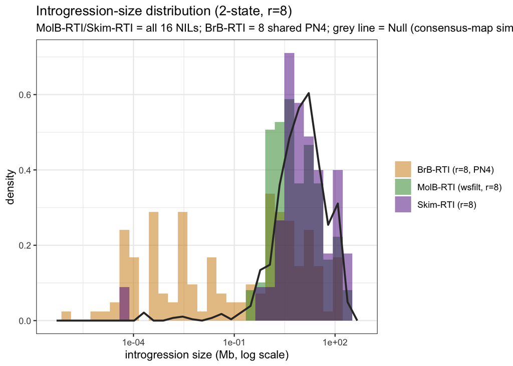

```r
molb_b <- donor_blocks(mb_s)   %>% mutate(src = "MolB-RTI (wsfilt, r=8)")
skim_b <- donor_blocks(skim_s) %>% mutate(src = "Skim-RTI (r=8)")
brb_b  <- donor_blocks(brb_s)  %>% mutate(src = "BrB-RTI (r=8, PN4)")
sim_b  <- donor_blocks(sim_seg)
ggplot(bind_rows(molb_b, skim_b, brb_b), aes(x = size_mb, fill = src)) +
  geom_histogram(aes(y = after_stat(density)), position = "identity", alpha = 0.5, bins = 30) +
  geom_freqpoly(data = sim_b, aes(x = size_mb, y = after_stat(density)),
                bins = 30, colour = "grey20", linewidth = 0.9, inherit.aes = FALSE) +
  scale_fill_manual(values = c("MolB-RTI (wsfilt, r=8)" = "forestgreen", "Skim-RTI (r=8)" = "purple4",
                               "BrB-RTI (r=8, PN4)" = "orange3")) +
  scale_x_log10() +
  labs(x = "introgression size (Mb, log scale)", y = "density", fill = NULL,
       title = "Introgression-size distribution (2-state, r=8)",
       subtitle = "MolB-RTI/Skim-RTI = all 16 NILs; BrB-RTI = 8 shared PN4; grey line = Null (consensus-map simulation)") +
  theme_bw()
```

## Donor-call composition — het vs homozygous donor

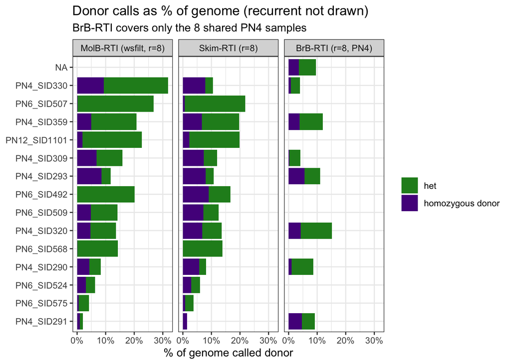

```r
# per-name marker total differs by source (MolB/Skim on full grid, BrB on its
# shared subset), so each carries its own denominator
tot_gs <- count(paired,   name, name = "tot")
tot_b  <- count(paired_b, name, name = "tot")
comp <- bind_rows(
  paired   %>% transmute(name, platform = "MolB-RTI (wsfilt, r=8)", state = molb) %>%
    filter(state %in% c(1,2)) %>% count(name, platform, state) %>% left_join(tot_gs, by = "name"),
  paired   %>% transmute(name, platform = "Skim-RTI (r=8)",        state = skim) %>%
    filter(state %in% c(1,2)) %>% count(name, platform, state) %>% left_join(tot_gs, by = "name"),
  paired_b %>% transmute(name, platform = "BrB-RTI (r=8, PN4)", state = brbseq) %>%
    filter(state %in% c(1,2)) %>% count(name, platform, state) %>% left_join(tot_b, by = "name")) %>%
  mutate(pct = n/tot, state = factor(state, c(1,2), c("het","homozygous donor")),
         platform = factor(platform, c("MolB-RTI (wsfilt, r=8)", "Skim-RTI (r=8)", "BrB-RTI (r=8, PN4)")))
ord <- paired %>% group_by(name) %>% summarise(d = mean(molb)/2) %>% arrange(d) %>% pull(name)
comp$name <- factor(comp$name, levels = ord)
ggplot(comp, aes(y = name, x = pct, fill = state)) +
  geom_col(position = "stack") + facet_wrap(~ platform) +
  scale_fill_manual(values = c("het" = "forestgreen", "homozygous donor" = "purple4")) +
  scale_x_continuous(labels = scales::percent) +
  labs(x = "% of genome called donor", y = NULL, fill = NULL,
       title = "Donor calls as % of genome (recurrent not drawn)",
       subtitle = "BrB-RTI covers only the 8 shared PN4 samples") + theme_bw()
```

## Chromosome painting — MolB-RTI vs Skim-RTI vs BrB-RTI

Full-genome ancestry painting, three lanes per sample: **top = MolB-RTI (wsfilt, r=8), middle = Skim-RTI (r=8), bottom = BrB-RTI (r=8)**. Chromosomes are proportional-width facet columns; segments are painted over their exact `start_bp→end_bp` extent (`geom_rect`). Palette follows the BzeaSeq convention (`REF` gold, `HET` springgreen4, `ALT` purple4). Lines are ordered by MolB-RTI donor dosage with the two B73-bulk checks pinned on top; `LowQuality` lines (sample-map QC flag) are in **bold**. The BrB-RTI lane is present only for the 8 shared PN4 samples — the other lines show a blank bottom lane (no BRB-seq counterpart in `run_full`).

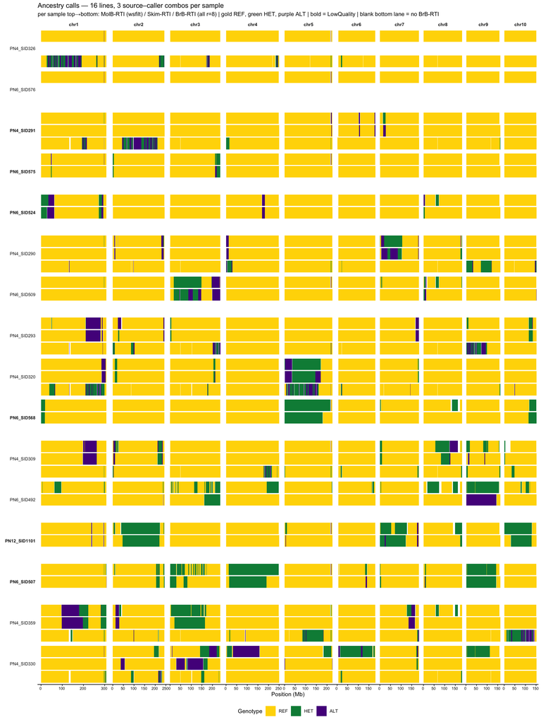

```r
pal <- c(REF = "gold", HET = "springgreen4", ALT = "purple4")
as_paint <- function(seg, method) tibble(
  name = seg$name, chr = seg$chr, start_bp = seg$start_bp, end_bp = seg$end_bp,
  state = factor(seg$state, 0:2, c("REF","HET","ALT")), method = method)

dose_ord <- mb %>% mutate(len = end_bp - start_bp + 1) %>% group_by(name) %>%
  summarise(d = sum(len * state/2)/sum(len), .groups = "drop")
ord  <- c(checks, dose_ord %>% filter(!name %in% checks) %>% arrange(d) %>% pull(name))
lowq <- smap$sample_id[smap$quality == "LowQuality" & !is.na(smap$quality)]
name_lab <- function(x) if_else(x %in% lowq, paste0("**", x, "**"), x)

paint3 <- bind_rows(
  as_paint(mb,                                      "MolB-RTI (wsfilt, r=8)"),
  as_paint(skim %>% filter(name %in% unique(mb$name)), "Skim-RTI (r=8)"),
  as_paint(brb,                                     "BrB-RTI (r=8)")) %>%
  mutate(chr    = factor(chr, levels = 1:10, labels = paste0("chr", 1:10)),
         name   = factor(name_lab(name), levels = name_lab(ord)),
         method = factor(method, c("MolB-RTI (wsfilt, r=8)","Skim-RTI (r=8)","BrB-RTI (r=8)")),
         ylo = case_when(method == "MolB-RTI (wsfilt, r=8)" ~ 0.69, method == "Skim-RTI (r=8)" ~ 0.35, TRUE ~ 0.00),
         yhi = case_when(method == "MolB-RTI (wsfilt, r=8)" ~ 1.00, method == "Skim-RTI (r=8)" ~ 0.66, TRUE ~ 0.32))

ggplot(paint3, aes(xmin = start_bp/1e6, xmax = end_bp/1e6,
                   ymin = ylo, ymax = yhi, fill = state)) +
  geom_rect() +
  facet_grid(name ~ chr, scales = "free_x", space = "free_x", switch = "y") +
  scale_fill_manual(values = pal, drop = FALSE) +
  scale_x_continuous(labels = scales::unit_format(unit = "", scale = 1)) +
  labs(title = "Ancestry calls — 16 lines, 3 source–caller combos per sample",
       subtitle = "per sample top→bottom: MolB-RTI (wsfilt) / Skim-RTI / BrB-RTI (all r=8) | gold REF, green HET, purple ALT | bold = LowQuality | blank bottom lane = no BrB-RTI",
       x = "Position (Mb)", fill = "Genotype") +
  ggpubr::theme_classic2(base_size = 9) +
  theme(legend.position = "bottom",
        strip.background = element_blank(),
        strip.text.x = element_text(face = "bold"),
        strip.text.y.left = ggtext::element_markdown(angle = 0, hjust = 1, size = 7),
        panel.spacing.x = unit(0.05, "lines"),
        panel.spacing.y = unit(0.05, "lines"),
        axis.text.y = element_blank(), axis.ticks.y = element_blank(),
        axis.title.y = element_blank(), axis.line.y = element_blank(),
        axis.text.x = element_text(size = 6))
```

**Read:** the BrB-RTI lane (bottom) is sparse and speckled relative to the MolB-RTI and Skim-RTI lanes — short, scattered donor blocks rather than the long contiguous introgressions MolB-RTI resolves, and present only for the 8 PN4 lines. It picks up the largest MolB-RTI donor regions in places but misses most, consistent with the ~13% marker-level donor recall above.